# Floods, huricanes, typhoons and tornados the greatest enviromental threats

## Results

The damages of an enviromental event are assessed according to two different criteria:

1. Human health damages which are assessed by quantifying the number of injures and fatalities.
2. Economic damages which are assessed by calculating the cost of the damages to properties and crops.

### 1 Human health damage:

In order to assess the damage impact to human health the driver parameter for the comparison is injuries even though fatalities is more severe. As this study assumes the hypothesis that injured people have higher impact for government in terms of cost, time and means than fatalities. The table below is arranged according to the events that gather more records of injured people. It is depicted that the top 3 most hazardous enviromental events for human health are tornados, floods and excessive heat.

```r
PeopleDMG <- b[order(b$INJURIES, decreasing = TRUE), ]
head(PeopleDMG)
```

```
##            EVTYPE FATALITIES INJURIES  EconomicDMG
## 7         TORNADO       1511    20667  24900370720
## 1           FLOOD        414     6758 148919611950
## 18 EXCESSIVE HEAT       1797     6391    500125700
## 45      LIGHTNING        651     4141    749975520
## 22      TSTM WIND        241     3629   5031941790
## 12    FLASH FLOOD        887     1674  16557105610
```

### 2 Economic damage

It is worth noting that next to the graph of the cost of damages is the total number of injures and fatalities reported for each of those enviromental events.

```r
library(ggplot2)
"Most harmful enviromental events to properties and crops"
```

```
## [1] "Most harmful enviromental events to properties and crops"
```

```r
p1 <- ggplot(data = cc[1:10, ], aes(x = EVTYPE, col = "Type of cost")) + ggtitle("Effects on properties") +
    geom_point(aes(y = EconomicDMG, col = "Total")) + geom_point(aes(y = AvgDMGperEvent,
    col = "Averaged")) + theme(axis.title.y = element_blank(), plot.title = element_text(lineheight = 0.8,
    face = "bold")) + scale_y_log10() + ylab("Cost of damage in $ (Log10)") +
    coord_flip()

"Effect on public health"
```

```
## [1] "Effect on public health"
```

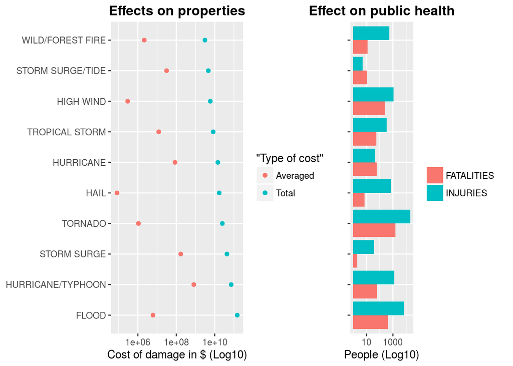

```r
library(reshape2)
mostDMG <- cc$EVTYPE[1:10]
PublicHealth <- melt(b, id = c("EVTYPE", "EconomicDMG"))
PublicHealth <- PublicHealth[PublicHealth$EVTYPE %in% mostDMG, ]
PublicHealth$EVTYPE <- factor(PublicHealth$EVTYPE)

p2 <- ggplot(PublicHealth, aes(x = EVTYPE, y = value, fill = variable)) + ggtitle("Effect on public health") +
    geom_bar(stat = "identity", position = "dodge") + scale_y_log10() + ylab("People (Log10)") +
    theme(axis.title.y = element_blank(), plot.title = element_text(lineheight = 0.8,
        face = "bold")) + scale_fill_discrete("") + theme(axis.text.y = element_blank(),
    axis.title.y = element_blank()) + coord_flip()

library(gridExtra)
grid.arrange(p1, p2, ncol = 2, widths = c(2, 1))
```